# IST 387 HW 6

##### Copyright 2021, Jeffrey Stanton, Jeffrey Saltz, and Jasmina Tacheva

```r
# Enter your name here: Ezra Cohen
```

### Attribution statement: (choose only one and delete the rest)

```r
# 1. I did this homework by myself, with help from the book and the professor.
# 2. I did this homework with help from the book and the professor and these Internet sources:
# 3. I did this homework with help from <Name of another student> but did not cut and paste any code.
```

**Reminders of things to practice from previous weeks:**  
Descriptive statistics: mean( )  
Install a package: install.packages( )  
?command: Ask R for help with a command

**This module:** **Data visualization** is important because many people can make sense of data more easily when it is presented in graphic form. As a data scientist, you will have to present complex data to decision makers in a form that makes the data interpretable for them. From your experience with Excel and other tools, you know that there are a variety of **common data visualizations** (e.g., pie charts). How many of them can you name?

The most powerful tool for data visualization in R is called **ggplot**. Written by computer/data scientist **Hadley Wickham**, this **“graphics grammar”** tool builds visualizations in layers. This method provides immense flexibility, but takes a bit of practice to master.

## Step 1: Make a copy of the data

```r
URL<-"https://ist387.s3.us-east-2.amazonaws.com/data/who.csv"
tb<-data.frame(read.csv(url(URL)))
tb
```

A data.frame: 5769 × 23

| iso2 <chr> | year <int> | new_sp <int> | new_sp_m04 <int> | new_sp_m514 <int> | new_sp_m014 <int> | new_sp_m1524 <int> | new_sp_m2534 <int> | new_sp_m3544 <int> | new_sp_m4554 <int> | ⋯ | new_sp_f04 <int> | new_sp_f514 <int> | new_sp_f014 <int> | new_sp_f1524 <int> | new_sp_f2534 <int> | new_sp_f3544 <int> | new_sp_f4554 <int> | new_sp_f5564 <int> | new_sp_f65 <int> | new_sp_fu <int> |
| --- | --- | --- | --- | --- | --- | --- | --- | --- | --- | --- | --- | --- | --- | --- | --- | --- | --- | --- | --- | --- |
| AD | 1989 | NA | NA | NA | NA | NA | NA | NA | NA | ⋯ | NA | NA | NA | NA | NA | NA | NA | NA | NA | NA |
| AD | 1990 | NA | NA | NA | NA | NA | NA | NA | NA | ⋯ | NA | NA | NA | NA | NA | NA | NA | NA | NA | NA |
| AD | 1991 | NA | NA | NA | NA | NA | NA | NA | NA | ⋯ | NA | NA | NA | NA | NA | NA | NA | NA | NA | NA |
| AD | 1992 | NA | NA | NA | NA | NA | NA | NA | NA | ⋯ | NA | NA | NA | NA | NA | NA | NA | NA | NA | NA |
| AD | 1993 | 15 | NA | NA | NA | NA | NA | NA | NA | ⋯ | NA | NA | NA | NA | NA | NA | NA | NA | NA | NA |
| AD | 1994 | 24 | NA | NA | NA | NA | NA | NA | NA | ⋯ | NA | NA | NA | NA | NA | NA | NA | NA | NA | NA |
| AD | 1996 | 8 | NA | NA | 0 | 0 | 0 | 4 | 1 | ⋯ | NA | NA | 0 | 1 | 1 | 0 | 0 | 1 | 0 | NA |
| AD | 1997 | 17 | NA | NA | 0 | 0 | 1 | 2 | 2 | ⋯ | NA | NA | 0 | 1 | 2 | 3 | 0 | 0 | 1 | NA |
| AD | 1998 | 1 | NA | NA | 0 | 0 | 0 | 1 | 0 | ⋯ | NA | NA | NA | NA | NA | NA | NA | NA | NA | NA |
| AD | 1999 | 4 | NA | NA | 0 | 0 | 0 | 1 | 1 | ⋯ | NA | NA | 0 | 0 | 0 | 1 | 0 | 0 | 0 | NA |
| AD | 2000 | 1 | NA | NA | 0 | 0 | 1 | 0 | 0 | ⋯ | NA | NA | NA | NA | NA | NA | NA | NA | NA | NA |
| AD | 2001 | 3 | NA | NA | 0 | NA | NA | 2 | 1 | ⋯ | NA | NA | NA | NA | NA | NA | NA | NA | NA | NA |
| AD | 2002 | 2 | NA | NA | 0 | 0 | 0 | 1 | 0 | ⋯ | NA | NA | 0 | 1 | 0 | 0 | 0 | 0 | 0 | NA |
| AD | 2003 | 7 | NA | NA | 0 | 0 | 0 | 1 | 2 | ⋯ | NA | NA | 0 | 1 | 1 | 1 | 0 | 0 | 0 | NA |
| AD | 2004 | 3 | NA | NA | 0 | 0 | 0 | 1 | 1 | ⋯ | NA | NA | 0 | 0 | 1 | 0 | 0 | 0 | 0 | NA |
| AD | 2005 | 5 | 0 | 0 | 0 | 0 | 1 | 1 | 0 | ⋯ | 0 | 0 | 0 | 1 | 1 | 1 | 0 | 0 | 0 | 0 |
| AD | 2006 | 8 | 0 | 0 | 0 | 1 | 1 | 2 | 0 | ⋯ | 0 | 0 | 0 | 0 | 1 | 0 | 1 | 0 | 0 | 0 |
| AD | 2007 | 2 | NA | NA | NA | NA | NA | NA | NA | ⋯ | NA | NA | NA | NA | 1 | NA | 1 | NA | NA | NA |
| AD | 2008 | 3 | 0 | 0 | 0 | 0 | 0 | 0 | 1 | ⋯ | 0 | 0 | 0 | 0 | 0 | 1 | 1 | 0 | 0 | 0 |
| AE | 1980 | NA | NA | NA | NA | NA | NA | NA | NA | ⋯ | NA | NA | NA | NA | NA | NA | NA | NA | NA | NA |
| AE | 1981 | NA | NA | NA | NA | NA | NA | NA | NA | ⋯ | NA | NA | NA | NA | NA | NA | NA | NA | NA | NA |
| AE | 1982 | NA | NA | NA | NA | NA | NA | NA | NA | ⋯ | NA | NA | NA | NA | NA | NA | NA | NA | NA | NA |
| AE | 1983 | NA | NA | NA | NA | NA | NA | NA | NA | ⋯ | NA | NA | NA | NA | NA | NA | NA | NA | NA | NA |
| AE | 1984 | NA | NA | NA | NA | NA | NA | NA | NA | ⋯ | NA | NA | NA | NA | NA | NA | NA | NA | NA | NA |
| AE | 1985 | NA | NA | NA | NA | NA | NA | NA | NA | ⋯ | NA | NA | NA | NA | NA | NA | NA | NA | NA | NA |
| AE | 1986 | NA | NA | NA | NA | NA | NA | NA | NA | ⋯ | NA | NA | NA | NA | NA | NA | NA | NA | NA | NA |
| AE | 1987 | NA | NA | NA | NA | NA | NA | NA | NA | ⋯ | NA | NA | NA | NA | NA | NA | NA | NA | NA | NA |
| AE | 1988 | NA | NA | NA | NA | NA | NA | NA | NA | ⋯ | NA | NA | NA | NA | NA | NA | NA | NA | NA | NA |
| AE | 1989 | NA | NA | NA | NA | NA | NA | NA | NA | ⋯ | NA | NA | NA | NA | NA | NA | NA | NA | NA | NA |
| AE | 1990 | NA | NA | NA | NA | NA | NA | NA | NA | ⋯ | NA | NA | NA | NA | NA | NA | NA | NA | NA | NA |
| ⋮ | ⋮ | ⋮ | ⋮ | ⋮ | ⋮ | ⋮ | ⋮ | ⋮ | ⋮ | ⋱ | ⋮ | ⋮ | ⋮ | ⋮ | ⋮ | ⋮ | ⋮ | ⋮ | ⋮ | ⋮ |
| ZM | 2008 | 13211 | NA | NA | 101 | 1120 | 3244 | 2094 | 737 | ⋯ | NA | NA | 165 | 1246 | 2062 | 1114 | 498 | 187 | 115 | 0 |
| ZW | 1980 | NA | NA | NA | NA | NA | NA | NA | NA | ⋯ | NA | NA | NA | NA | NA | NA | NA | NA | NA | NA |
| ZW | 1981 | NA | NA | NA | NA | NA | NA | NA | NA | ⋯ | NA | NA | NA | NA | NA | NA | NA | NA | NA | NA |
| ZW | 1982 | NA | NA | NA | NA | NA | NA | NA | NA | ⋯ | NA | NA | NA | NA | NA | NA | NA | NA | NA | NA |
| ZW | 1983 | NA | NA | NA | NA | NA | NA | NA | NA | ⋯ | NA | NA | NA | NA | NA | NA | NA | NA | NA | NA |
| ZW | 1984 | NA | NA | NA | NA | NA | NA | NA | NA | ⋯ | NA | NA | NA | NA | NA | NA | NA | NA | NA | NA |
| ZW | 1985 | NA | NA | NA | NA | NA | NA | NA | NA | ⋯ | NA | NA | NA | NA | NA | NA | NA | NA | NA | NA |
| ZW | 1986 | NA | NA | NA | NA | NA | NA | NA | NA | ⋯ | NA | NA | NA | NA | NA | NA | NA | NA | NA | NA |
| ZW | 1987 | NA | NA | NA | NA | NA | NA | NA | NA | ⋯ | NA | NA | NA | NA | NA | NA | NA | NA | NA | NA |
| ZW | 1988 | NA | NA | NA | NA | NA | NA | NA | NA | ⋯ | NA | NA | NA | NA | NA | NA | NA | NA | NA | NA |
| ZW | 1989 | NA | NA | NA | NA | NA | NA | NA | NA | ⋯ | NA | NA | NA | NA | NA | NA | NA | NA | NA | NA |
| ZW | 1990 | NA | NA | NA | NA | NA | NA | NA | NA | ⋯ | NA | NA | NA | NA | NA | NA | NA | NA | NA | NA |
| ZW | 1991 | NA | NA | NA | NA | NA | NA | NA | NA | ⋯ | NA | NA | NA | NA | NA | NA | NA | NA | NA | NA |
| ZW | 1992 | NA | NA | NA | NA | NA | NA | NA | NA | ⋯ | NA | NA | NA | NA | NA | NA | NA | NA | NA | NA |
| ZW | 1993 | 5331 | NA | NA | NA | NA | NA | NA | NA | ⋯ | NA | NA | NA | NA | NA | NA | NA | NA | NA | NA |
| ZW | 1994 | NA | NA | NA | NA | NA | NA | NA | NA | ⋯ | NA | NA | NA | NA | NA | NA | NA | NA | NA | NA |
| ZW | 1995 | 8965 | NA | NA | NA | NA | NA | NA | NA | ⋯ | NA | NA | NA | NA | NA | NA | NA | NA | NA | NA |
| ZW | 1996 | 11965 | NA | NA | NA | NA | NA | NA | NA | ⋯ | NA | NA | NA | NA | NA | NA | NA | NA | NA | NA |
| ZW | 1997 | 14512 | NA | NA | NA | NA | NA | NA | NA | ⋯ | NA | NA | NA | NA | NA | NA | NA | NA | NA | NA |
| ZW | 1998 | 14492 | NA | NA | NA | NA | NA | NA | NA | ⋯ | NA | NA | NA | NA | NA | NA | NA | NA | NA | NA |
| ZW | 1999 | 14414 | NA | NA | NA | NA | NA | NA | NA | ⋯ | NA | NA | NA | NA | NA | NA | NA | NA | NA | NA |
| ZW | 2000 | 14392 | NA | NA | NA | NA | NA | NA | NA | ⋯ | NA | NA | NA | NA | NA | NA | NA | NA | NA | NA |
| ZW | 2001 | 15370 | NA | NA | NA | NA | NA | NA | NA | ⋯ | NA | NA | NA | NA | NA | NA | NA | NA | NA | NA |
| ZW | 2002 | 15941 | NA | NA | 191 | 600 | 2548 | 1662 | 744 | ⋯ | NA | NA | 222 | 914 | 2185 | 1095 | 421 | 140 | 65 | NA |
| ZW | 2003 | 14488 | NA | NA | 133 | 874 | 3048 | 2228 | 981 | ⋯ | NA | NA | 180 | 1232 | 2856 | 1480 | 565 | 225 | 114 | NA |
| ZW | 2004 | 14581 | NA | NA | 187 | 833 | 2908 | 2298 | 1056 | ⋯ | NA | NA | 225 | 1140 | 2858 | 1565 | 622 | 214 | 111 | NA |
| ZW | 2005 | 13155 | NA | NA | 210 | 837 | 2264 | 1855 | 762 | ⋯ | NA | NA | 269 | 1136 | 2242 | 1255 | 578 | 193 | 603 | NA |
| ZW | 2006 | 12718 | NA | NA | 215 | 736 | 2391 | 1939 | 896 | ⋯ | NA | NA | 237 | 1020 | 2424 | 1355 | 632 | 230 | 96 | NA |
| ZW | 2007 | 10583 | 6 | 132 | 138 | 500 | 3693 | 0 | 716 | ⋯ | 7 | 178 | 185 | 739 | 3311 | 0 | 553 | 213 | 90 | NA |
| ZW | 2008 | 9830 | NA | NA | 127 | 614 | 0 | 3316 | 704 | ⋯ | NA | NA | 145 | 840 | 0 | 2890 | 467 | 174 | 105 | 0 |

B. How often were these measurements taken (in other words, at what frequency were the variables measured)? Put your answer in a comment.

```r
#not very frequently because most collumns have more NAs than numbers
```

## Step 2: Clean-up the NAs with Missing Data Mitigation

A. Create a subset of **tb** containing **only the records for Canada** (**"CA" in the iso2 variable**). Save it in a new dataframe called **tbCan**. Make sure this new df has **52 observations** and **23 variables**.

```r
tbCan<-tb[tb$iso2=="CA",]
tbCan
```

A data.frame: 52 × 23

|  | iso2 <chr> | year <int> | new_sp <int> | new_sp_m04 <int> | new_sp_m514 <int> | new_sp_m014 <int> | new_sp_m1524 <int> | new_sp_m2534 <int> | new_sp_m3544 <int> | new_sp_m4554 <int> | ⋯ | new_sp_f04 <int> | new_sp_f514 <int> | new_sp_f014 <int> | new_sp_f1524 <int> | new_sp_f2534 <int> | new_sp_f3544 <int> | new_sp_f4554 <int> | new_sp_f5564 <int> | new_sp_f65 <int> | new_sp_fu <int> |
| --- | --- | --- | --- | --- | --- | --- | --- | --- | --- | --- | --- | --- | --- | --- | --- | --- | --- | --- | --- | --- | --- |
| 872 | CA | 1980 | 951 | NA | NA | 12 | 54 | 75 | 83 | 100 | ⋯ | NA | NA | 18 | 62 | 51 | 34 | 31 | 33 | 104 | NA |
| 873 | CA | 1981 | 803 | NA | NA | 8 | 49 | 61 | 64 | 87 | ⋯ | NA | NA | 6 | 46 | 57 | 26 | 28 | 35 | 92 | NA |
| 874 | CA | 1982 | 812 | NA | NA | 6 | 52 | 66 | 69 | 90 | ⋯ | NA | NA | 7 | 51 | 57 | 30 | 25 | 38 | 80 | NA |
| 875 | CA | 1983 | 771 | NA | NA | 9 | 47 | 63 | 62 | 90 | ⋯ | NA | NA | 11 | 50 | 50 | 29 | 24 | 35 | 86 | NA |
| 876 | CA | 1984 | 811 | NA | NA | 3 | 44 | 75 | 58 | 68 | ⋯ | NA | NA | 9 | 51 | 59 | 28 | 28 | 36 | 100 | NA |
| 877 | CA | 1985 | 791 | NA | NA | 11 | 42 | 70 | 59 | 77 | ⋯ | NA | NA | 5 | 30 | 56 | 19 | 28 | 48 | 97 | NA |
| 878 | CA | 1986 | 752 | NA | NA | 9 | 58 | 73 | 62 | 59 | ⋯ | NA | NA | 10 | 33 | 54 | 33 | 20 | 26 | 95 | NA |
| 879 | CA | 1987 | 668 | NA | NA | 9 | 40 | 71 | 60 | 49 | ⋯ | NA | NA | 8 | 39 | 48 | 29 | 17 | 26 | 79 | NA |
| 880 | CA | 1988 | 682 | NA | NA | 4 | 43 | 73 | 62 | 52 | ⋯ | NA | NA | 6 | 38 | 56 | 27 | 16 | 26 | 80 | NA |
| 881 | CA | 1989 | 652 | NA | NA | 10 | 45 | 56 | 60 | 54 | ⋯ | NA | NA | 6 | 37 | 51 | 23 | 24 | 21 | 81 | NA |
| 882 | CA | 1990 | 549 | NA | NA | 3 | 35 | 70 | 55 | 40 | ⋯ | NA | NA | 1 | 30 | 38 | 26 | 17 | 20 | 72 | NA |
| 883 | CA | 1991 | 543 | NA | NA | 7 | 37 | 79 | 53 | 37 | ⋯ | NA | NA | 4 | 23 | 37 | 31 | 9 | 20 | 60 | NA |
| 884 | CA | 1992 | 506 | NA | NA | 6 | 42 | 47 | 58 | 41 | ⋯ | NA | NA | 2 | 27 | 28 | 21 | 11 | 15 | 78 | NA |
| 885 | CA | 1993 | 488 | NA | NA | 8 | 33 | 47 | 53 | 43 | ⋯ | NA | NA | 6 | 22 | 50 | 22 | 21 | 21 | 55 | NA |
| 886 | CA | 1994 | 483 | NA | NA | 2 | 42 | 54 | 42 | 43 | ⋯ | NA | NA | 3 | 37 | 37 | 19 | 11 | 13 | 59 | NA |
| 887 | CA | 1995 | 436 | NA | NA | 1 | 28 | 31 | 60 | 34 | ⋯ | NA | NA | 7 | 33 | 28 | 22 | 12 | 18 | 51 | NA |
| 888 | CA | 1996 | 430 | NA | NA | 3 | 28 | 49 | 48 | 31 | ⋯ | NA | NA | 2 | 23 | 34 | 28 | 14 | 16 | 50 | NA |
| 889 | CA | 1997 | 473 | NA | NA | 0 | 21 | 55 | 44 | 30 | ⋯ | NA | NA | 1 | 36 | 44 | 26 | 13 | 16 | 53 | NA |
| 890 | CA | 1998 | 438 | NA | NA | 4 | 33 | 43 | 51 | 31 | ⋯ | NA | NA | 1 | 26 | 31 | 26 | 14 | 18 | 54 | NA |
| 891 | CA | 1999 | 455 | NA | NA | 0 | 23 | 47 | 51 | 36 | ⋯ | NA | NA | 4 | 33 | 31 | 28 | 13 | 11 | 51 | NA |
| 892 | CA | 2000 | 492 | NA | NA | 5 | 34 | 45 | 46 | 41 | ⋯ | NA | NA | 4 | 33 | 40 | 30 | 25 | 12 | 66 | NA |
| 893 | CA | 2001 | 458 | NA | NA | 6 | 24 | 49 | 56 | 40 | ⋯ | NA | NA | 5 | 23 | 41 | 33 | 16 | 14 | 53 | NA |
| 894 | CA | 2002 | 408 | NA | NA | 0 | 25 | 34 | 50 | 34 | ⋯ | NA | NA | 6 | 32 | 31 | 26 | 17 | 17 | 45 | NA |
| 895 | CA | 2003 | 332 | NA | NA | 1 | 26 | 36 | 37 | 32 | ⋯ | NA | NA | 3 | 21 | 28 | 25 | 15 | 9 | 36 | NA |
| 896 | CA | 2004 | 438 | NA | NA | 2 | 25 | 34 | 38 | 32 | ⋯ | NA | NA | 0 | 34 | 55 | 34 | 19 | 22 | 48 | NA |
| 897 | CA | 2005 | 433 | NA | NA | 3 | 37 | 45 | 44 | 40 | ⋯ | NA | NA | 6 | 28 | 40 | 27 | 24 | 13 | 37 | NA |
| 898 | CA | 2006 | 407 | 1 | 1 | 2 | 34 | 34 | 33 | 42 | ⋯ | 0 | 4 | 4 | 39 | 30 | 25 | 16 | 6 | 52 | NA |
| 899 | CA | 2007 | 463 | 4 | 1 | 5 | 31 | 41 | 51 | 50 | ⋯ | 0 | 2 | 2 | 32 | 33 | 33 | 11 | 13 | 51 | NA |
| 900 | CA | 2008 | 488 | 0 | 2 | 2 | 39 | 36 | 49 | 53 | ⋯ | 0 | 3 | 3 | 36 | 39 | 39 | 27 | 20 | 45 | 0 |
| NA | NA | NA | NA | NA | NA | NA | NA | NA | NA | NA | ⋯ | NA | NA | NA | NA | NA | NA | NA | NA | NA | NA |
| NA.1 | NA | NA | NA | NA | NA | NA | NA | NA | NA | NA | ⋯ | NA | NA | NA | NA | NA | NA | NA | NA | NA | NA |
| NA.2 | NA | NA | NA | NA | NA | NA | NA | NA | NA | NA | ⋯ | NA | NA | NA | NA | NA | NA | NA | NA | NA | NA |
| NA.3 | NA | NA | NA | NA | NA | NA | NA | NA | NA | NA | ⋯ | NA | NA | NA | NA | NA | NA | NA | NA | NA | NA |
| NA.4 | NA | NA | NA | NA | NA | NA | NA | NA | NA | NA | ⋯ | NA | NA | NA | NA | NA | NA | NA | NA | NA | NA |
| NA.5 | NA | NA | NA | NA | NA | NA | NA | NA | NA | NA | ⋯ | NA | NA | NA | NA | NA | NA | NA | NA | NA | NA |
| NA.6 | NA | NA | NA | NA | NA | NA | NA | NA | NA | NA | ⋯ | NA | NA | NA | NA | NA | NA | NA | NA | NA | NA |
| NA.7 | NA | NA | NA | NA | NA | NA | NA | NA | NA | NA | ⋯ | NA | NA | NA | NA | NA | NA | NA | NA | NA | NA |
| NA.8 | NA | NA | NA | NA | NA | NA | NA | NA | NA | NA | ⋯ | NA | NA | NA | NA | NA | NA | NA | NA | NA | NA |
| NA.9 | NA | NA | NA | NA | NA | NA | NA | NA | NA | NA | ⋯ | NA | NA | NA | NA | NA | NA | NA | NA | NA | NA |
| NA.10 | NA | NA | NA | NA | NA | NA | NA | NA | NA | NA | ⋯ | NA | NA | NA | NA | NA | NA | NA | NA | NA | NA |
| NA.11 | NA | NA | NA | NA | NA | NA | NA | NA | NA | NA | ⋯ | NA | NA | NA | NA | NA | NA | NA | NA | NA | NA |
| NA.12 | NA | NA | NA | NA | NA | NA | NA | NA | NA | NA | ⋯ | NA | NA | NA | NA | NA | NA | NA | NA | NA | NA |
| NA.13 | NA | NA | NA | NA | NA | NA | NA | NA | NA | NA | ⋯ | NA | NA | NA | NA | NA | NA | NA | NA | NA | NA |
| NA.14 | NA | NA | NA | NA | NA | NA | NA | NA | NA | NA | ⋯ | NA | NA | NA | NA | NA | NA | NA | NA | NA | NA |
| NA.15 | NA | NA | NA | NA | NA | NA | NA | NA | NA | NA | ⋯ | NA | NA | NA | NA | NA | NA | NA | NA | NA | NA |
| NA.16 | NA | NA | NA | NA | NA | NA | NA | NA | NA | NA | ⋯ | NA | NA | NA | NA | NA | NA | NA | NA | NA | NA |
| NA.17 | NA | NA | NA | NA | NA | NA | NA | NA | NA | NA | ⋯ | NA | NA | NA | NA | NA | NA | NA | NA | NA | NA |
| NA.18 | NA | NA | NA | NA | NA | NA | NA | NA | NA | NA | ⋯ | NA | NA | NA | NA | NA | NA | NA | NA | NA | NA |
| NA.19 | NA | NA | NA | NA | NA | NA | NA | NA | NA | NA | ⋯ | NA | NA | NA | NA | NA | NA | NA | NA | NA | NA |
| NA.20 | NA | NA | NA | NA | NA | NA | NA | NA | NA | NA | ⋯ | NA | NA | NA | NA | NA | NA | NA | NA | NA | NA |
| NA.21 | NA | NA | NA | NA | NA | NA | NA | NA | NA | NA | ⋯ | NA | NA | NA | NA | NA | NA | NA | NA | NA | NA |
| NA.22 | NA | NA | NA | NA | NA | NA | NA | NA | NA | NA | ⋯ | NA | NA | NA | NA | NA | NA | NA | NA | NA | NA |

A simple method for dealing with small amounts of **missing data** in a numeric variable is to **substitute the mean of the variable in place of each missing datum**. This expression locates (and reports to the console) all the missing data elements in the variable measuring the **number of positive pulmonary smear tests for male children 0-14 years old**:

```r
tbCan$new_sp_m014[is.na(tbCan$new_sp_m014)]
```

1. <NA>

2. <NA>

3. <NA>

4. <NA>

5. <NA>

6. <NA>

7. <NA>

8. <NA>

9. <NA>

10. <NA>

11. <NA>

12. <NA>

13. <NA>

14. <NA>

15. <NA>

16. <NA>

17. <NA>

18. <NA>

19. <NA>

20. <NA>

21. <NA>

22. <NA>

23. <NA>

B. Write a comment describing how that statement works.

```r
#it takes all the data at an index where na is true
```

C. Write one more statement to report missing data for the number of positive pulmonary smear tests for **female** children 0-14 years old, and a statement for the number of positive pulmonary smear tests for the **male and female citizens 65 years of age and older**, respectively.

```r
tbCan$new_sp_f014[is.na(tbCan$new_sp_f014)]
sum(tbCan$new_sp_m65[!is.na(tbCan$new_sp_m65)] + tbCan$new_sp_f65[!is.na(tbCan$new_sp_f65)]) #initialy just had this
tbCan$new_sp_m65[!is.na(tbCan$new_sp_m65)] + tbCan$new_sp_f65[!is.na(tbCan$new_sp_f65)] #put this in because sam made good point that we don't know which way we should have done it
```

1. <NA>

2. <NA>

3. <NA>

4. <NA>

5. <NA>

6. <NA>

7. <NA>

8. <NA>

9. <NA>

10. <NA>

11. <NA>

12. <NA>

13. <NA>

14. <NA>

15. <NA>

16. <NA>

17. <NA>

18. <NA>

19. <NA>

20. <NA>

21. <NA>

22. <NA>

23. <NA>

4824

1. 290

2. 233

3. 230

4. 209

5. 269

6. 265

7. 242

8. 208

9. 211

10. 203

11. 172

12. 170

13. 157

14. 129

15. 146

16. 121

17. 120

18. 143

19. 134

20. 145

21. 145

22. 129

23. 109

24. 78

25. 112

26. 105

27. 116

28. 126

29. 107

There is an R package called **imputeTS** specifically designed to repair missing values in time series data. We will use this instead of mean substitution.  
The **na_interpolation()** function in this package takes advantage of a unique characteristic of time series data: **neighboring points in time can be used to “guess” about a missing value in between**.

D. Install the **imputeTS** package and use **na_interpolation( )** on the four variables whose missing values you reported on in B & C. Don’t forget that you need to save the results back to the **tbCan** dataframe.

```r
install.packages("imputeTS")
library(imputeTS)
tbCan$new_sp_m014<-na_interpolation(tbCan$new_sp_m014)
tbCan$new_sp_f014<-na_interpolation(tbCan$new_sp_f014)
tbCan$new_sp_f65<-na_interpolation(tbCan$new_sp_f65)
tbCan$new_sp_m65<-na_interpolation(tbCan$new_sp_m65)
```

```
Updating HTML index of packages in '.Library'

Making 'packages.html' ...
 done
```

E. Rerun the code from B & C above to check that all missing data have been fixed.

```r
tbCan$new_sp_m014[is.na(tbCan$new_sp_m014)]
tbCan$new_sp_f014[is.na(tbCan$new_sp_f014)]
sum(tbCan$new_sp_m65[!is.na(tbCan$new_sp_m65)] + tbCan$new_sp_f65[!is.na(tbCan$new_sp_f65)]) #initialy just had this
tbCan$new_sp_m65[!is.na(tbCan$new_sp_m65)] + tbCan$new_sp_f65[!is.na(tbCan$new_sp_f65)] #put this in because sam made good point that we don't know which way we should have done it
```

7285

1. 290

2. 233

3. 230

4. 209

5. 269

6. 265

7. 242

8. 208

9. 211

10. 203

11. 172

12. 170

13. 157

14. 129

15. 146

16. 121

17. 120

18. 143

19. 134

20. 145

21. 145

22. 129

23. 109

24. 78

25. 112

26. 105

27. 116

28. 126

29. 107

30. 107

31. 107

32. 107

33. 107

34. 107

35. 107

36. 107

37. 107

38. 107

39. 107

40. 107

41. 107

42. 107

43. 107

44. 107

45. 107

46. 107

47. 107

48. 107

49. 107

50. 107

51. 107

52. 107

## Step 3: Use ggplot to explore the distribution of each variable

**Don’t forget to install and library the ggplot2 package.** Then:  
F. Create a histogram for **new_sp_m014**. Be sure to add a title and briefly describe what the histogram means in a comment.

```r
install.packages("ggplot2")
library(ggplot2)
```

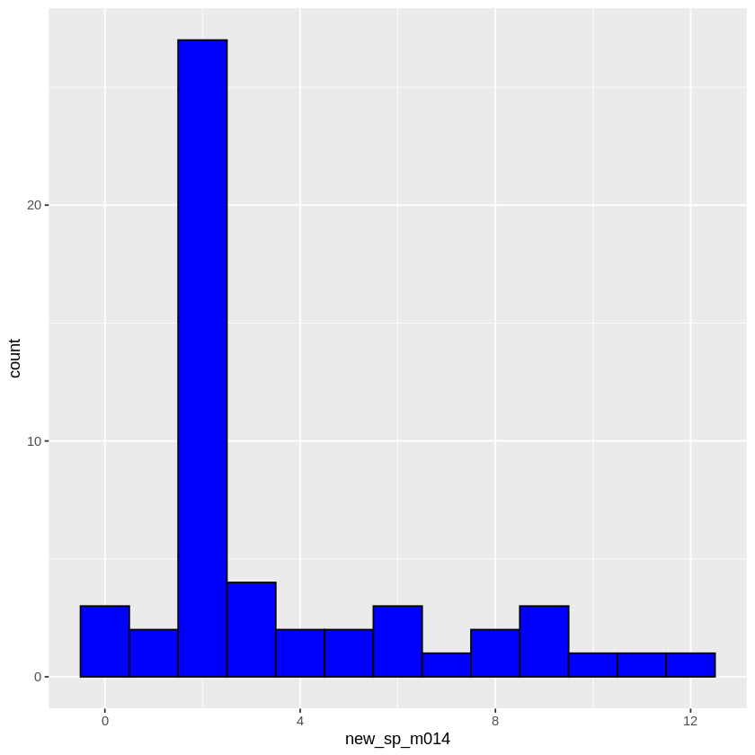

```r
m014<-ggplot(tbCan,aes(x=new_sp_m014))+geom_histogram(binwidth=1,color="black",fill="blue")
m014
```

G. Create histograms of each of the other three variables with ggplot( ).  
Which parameter do you need to adjust to make the other histograms look right?

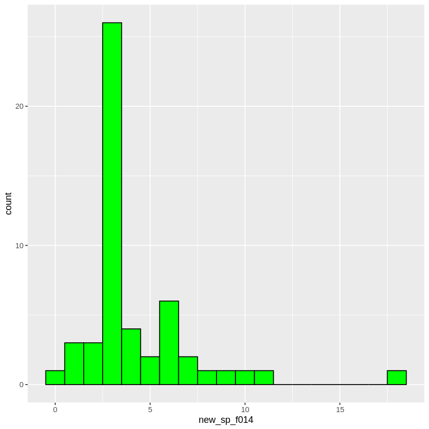

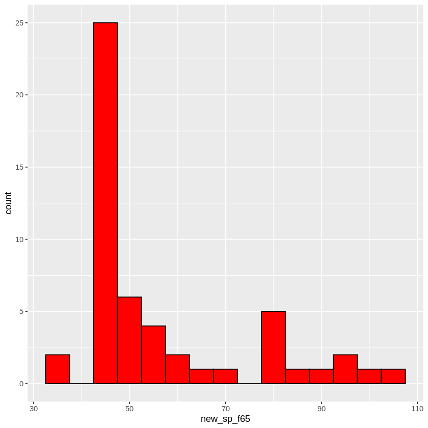

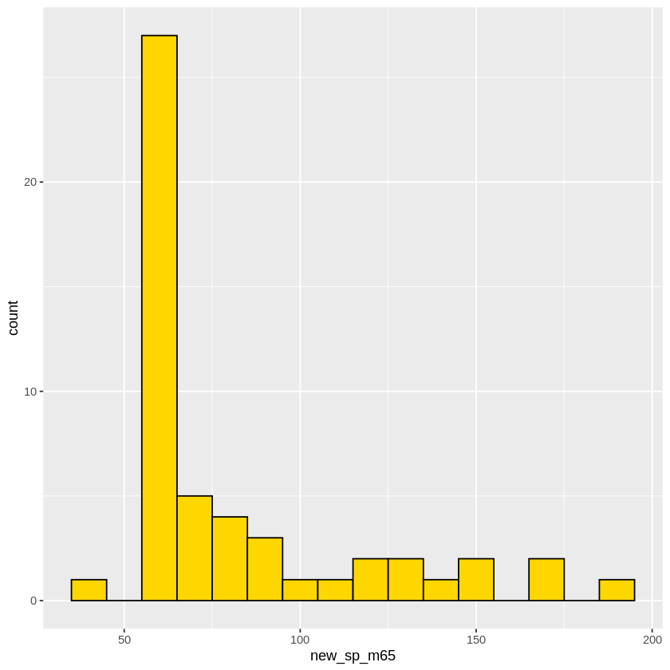

```r
f014<-ggplot(tbCan,aes(x=new_sp_f014))+geom_histogram(binwidth=1,color="black",fill="green")
f014
f65<-ggplot(tbCan,aes(x=new_sp_f65))+geom_histogram(binwidth=5,color="black",fill="red")
f65
m65<-ggplot(tbCan,aes(x=new_sp_m65))+geom_histogram(binwidth=10,color="black",fill="gold")
m65
```

## Step 4: Explore how the data changes over time

H. These data were collected in a period of several decades. You can thus observe changes over time with the help of a line chart. Create a **line chart**, with **year** on the X-axis and **new_sp_m014** on the Y-axis.

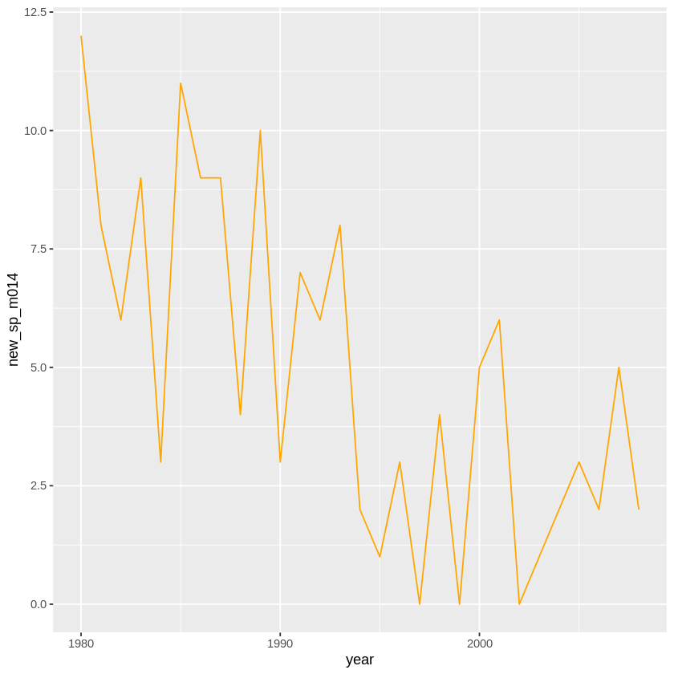

```r
m014_2<-ggplot(tbCan,aes(x=year,y=new_sp_m014))+geom_line(color="orange")
m014_2
```

I. Next, create similar graphs for each of the other three variables. Change the **color** of the line plots (any color you want).

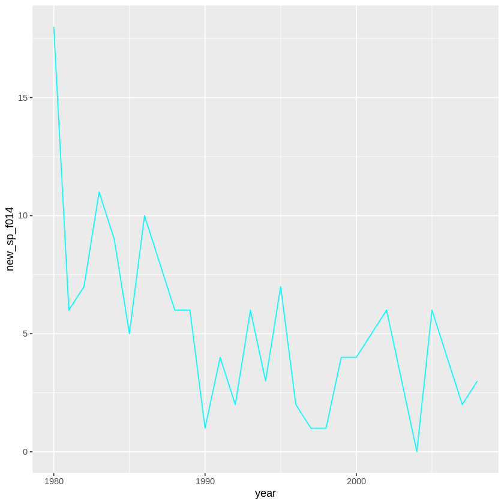

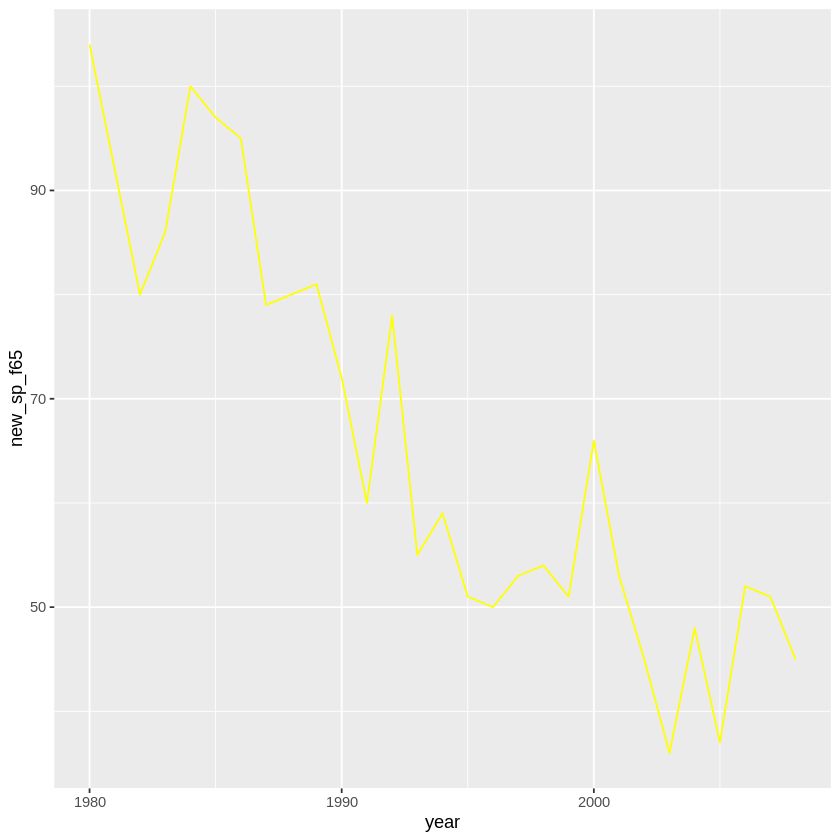

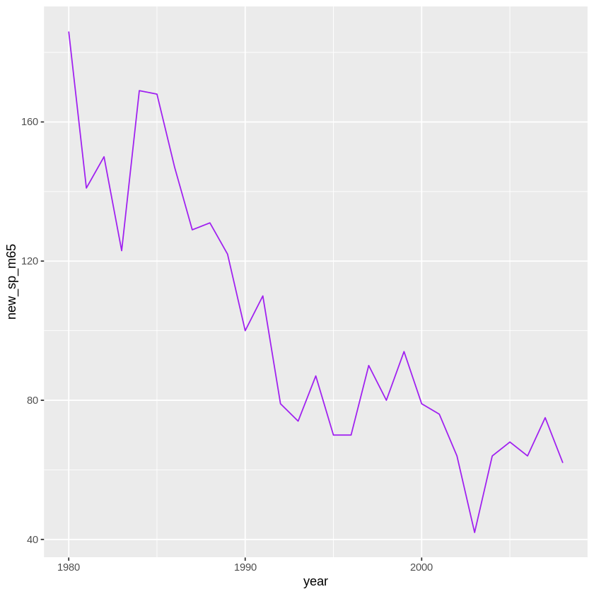

```r
f014_2<-ggplot(tbCan,aes(x=year,y=new_sp_f014))+geom_line(color="cyan")
f014_2
f65_2<-ggplot(tbCan,aes(x=year,y=new_sp_f65))+geom_line(color="yellow")
f65_2
m65_2<-ggplot(tbCan,aes(x=year,y=new_sp_m65))+geom_line(color="purple")
m65_2
```

J. Using vector math, create a new variable by combining the numbers from **new_sp_m014** and **new_sp_f014**. Save the resulting vector as a new variable in the **tbCan** df called **new_sp_combined014**. This new variable represents the number of positive pulmonary smear tests for male AND female children between the ages of 0 and 14 years of age. Do the same for SP **tests among citizens 65 years of age and older** and save the resulting vector in the tbCan variable called **new_sp_combined65**.

```r
tbCan$new_sp_combined014<- tbCan$new_sp_m014 + tbCan$new_sp_f014
tbCan$new_sp_combined65<- tbCan$new_sp_m65 + tbCan$new_sp_f65
```

K. Finally, create a **scatter plot**, showing **new_sp_combined014** on the x axis, **new_sp_combined65** on the y axis, and having the **color and size** of the point represent **year**.

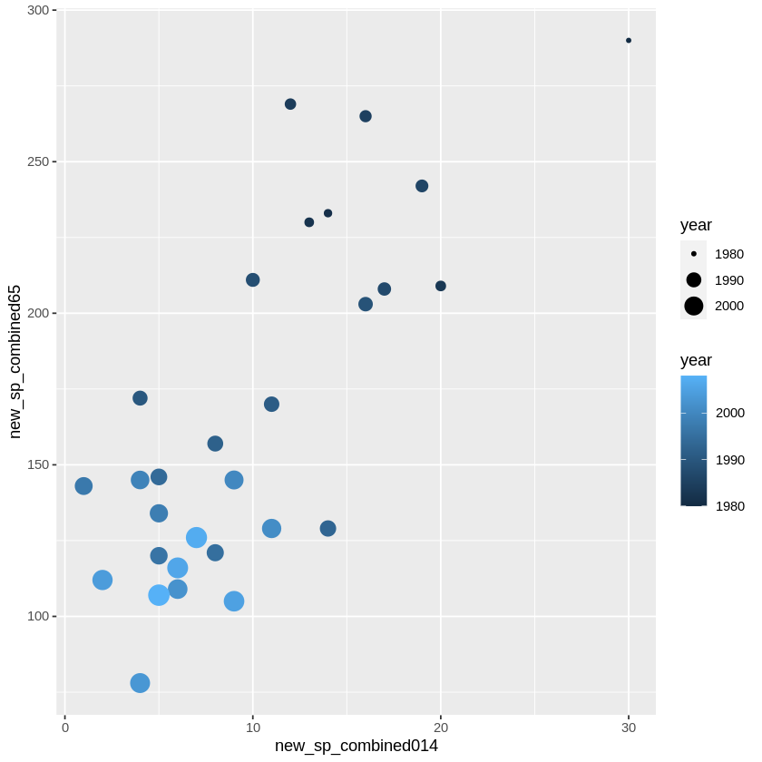

```r
scatterplot<- ggplot(tbCan,aes(x=new_sp_combined014,y=new_sp_combined65))+geom_point(aes(color=year,size=year))
scatterplot
```

L. Interpret this visualization – what insight does it provide?